# Integrated population model for Auke Creek coho salmon

2020-08-09

[**Mark D. Scheuerell**](https://faculty.washington.edu/scheuerl/)  
*Fish Ecology Division, Northwest Fisheries Science Center, National Marine Fisheries Service, National Oceanic and Atmospheric Administration, Seattle, WA, mark.scheuerell@noaa.gov*

**Eric R. Buhle**  
*Quantitative Science Inc., Northwest Fisheries Science Center, National Marine Fisheries Service, National Oceanic and Atmospheric Administration, Seattle, WA USA, eric.buhle@noaa.gov*

Note that author list and order subject to change. ***

# Requirements

All analyses require the [R software](https://cran.r-project.org/) (v3.4+) for data retrieval, data processing, and summarizing model results, and the [Stan software](http://mc-stan.org/) (v2.17.0) for Hamiltonian Monte Carlo (HMC) sampling.

We also need a few packages that are not included with the base installation of R, so we begin by installing them (if necessary) and then loading them.

```r
options(device = ifelse(.Platform$OS.type == "windows", "windows", "quartz"))
options(mc.cores = parallel::detectCores(logical = FALSE) - 1)

if(!require(rstan)) install.packages("rstan")
library(rstan)
if(!require(salmonIPM)) devtools::install_github("ebuhle/salmonIPM")
library(salmonIPM)
if(!require(here)) install.packages("here")
library(here)
if(!require(matrixStats)) install.packages("matrixStats")
library(matrixStats)
if(!require(yarrr)) install.packages("yarrr")
library(yarrr)
if(!require(Hmisc)) install.packages("Hmisc")
library(Hmisc)
if(!require(viridis)) install.packages("viridis")
library(viridis)

if(file.exists(here("analysis","results","auke_coho_ipm.RData")))
  load(here("analysis","results","auke_coho_ipm.RData"))
```

# Load Data

We begin by reading in the fish data file assembled in Phase I. Specifically, it is a **.csv** file with the following columns:

- `pop`: Numeric or character population ID.
- `year`: Numeric variable giving the year the fish spawned (i.e., the brood year).
- `A`: Spawning habitat size (either stream length or area).
- `S_tot_obs`: Total number (not density) of wild and hatchery-origin spawners.
- `n_age_minAge`…`n_age_maxAge`: Multiple columns of the observed age distribution, where minAge (maxAge) is the numeral total age in years of the youngest (oldest) spawners.
- `n_W_obs`: Observed frequency of natural-origin spawners.
- `n_H_obs`: Observed frequency of hatchery-origin spawners.
- `fit_p_HOS`: Logical or 0/1 indicating if, for each row in the data, the model should estimate p_HOS > 0.
- `F_rate`: Total harvest rate (proportion) of natural-origin fish.
- `B_take_obs`: Number of adults taken for hatchery broodstock.

```r
# Coho population data
fish_data <- read.csv(here("data","auke_coho_data_1980-2019.csv"))

# Environmental covariate data
cov_raw <- read.csv(here("data","covariates_1980-2019.csv"))

# Standardize covariates for modeling
env_data <- cov_raw
env_data[,-1] <- scale(env_data[,-1])
```

# Fit Models

## Density-Independent

```r
fit_exp <- salmonIPM(fish_data = fish_data,
                     stan_model = "IPM_SMaS_np", SR_fun = "exp", conditionGRonMS = TRUE,
                     pars = "Rmax", include = FALSE, log_lik = TRUE,
                     chains = 3, cores = 3, iter = 1500, warmup = 500,
                     control = list(adapt_delta = 0.99, max_treedepth = 13))
```

```r
print(fit_exp,  probs = c(0.025,0.5,0.975),
      pars = c("p_M","q_M","s_MS","p_MS","q_MS","q_GR","M","S","R","B_rate_all","LL"),
      include = FALSE)
```

```
Inference for Stan model: IPM_SMaS_np.
3 chains, each with iter=1500; warmup=500; thin=1;
post-warmup draws per chain=1000, total post-warmup draws=3000.

                       mean se_mean    sd      2.5%       50%     97.5% n_eff Rhat
alpha[1]               6.57    0.02  0.89      5.10      6.50      8.54  1361 1.00
rho_M[1]               0.43    0.01  0.20      0.01      0.45      0.76  1355 1.00
sigma_M[1]             0.35    0.00  0.07      0.22      0.35      0.49   793 1.00
tau_M[1]               0.11    0.00  0.05      0.04      0.11      0.22   288 1.01
mu_p_M[1,1]            0.55    0.00  0.02      0.51      0.55      0.60   849 1.01
mu_p_M[1,2]            0.45    0.00  0.02      0.40      0.45      0.49   849 1.01
sigma_p_M[1,1]         0.54    0.00  0.07      0.42      0.53      0.70  1578 1.00
R_p_M[1,1,1]           1.00     NaN  0.00      1.00      1.00      1.00   NaN  NaN
mu_MS[1,1]             0.14    0.00  0.03      0.10      0.14      0.21  1160 1.00
mu_MS[1,2]             0.29    0.00  0.07      0.17      0.29      0.45  1453 1.00
rho_MS[1,1]            0.51    0.00  0.16      0.16      0.52      0.79  1235 1.00
rho_MS[1,2]            0.68    0.00  0.12      0.41      0.69      0.85  1687 1.00
sigma_MS[1,1]          0.57    0.00  0.09      0.42      0.56      0.77  1028 1.00
sigma_MS[1,2]          0.62    0.00  0.11      0.42      0.61      0.85  1111 1.00
R_MS[1,1,1]            1.00     NaN  0.00      1.00      1.00      1.00   NaN  NaN
R_MS[1,1,2]           -0.08    0.01  0.20     -0.47     -0.07      0.32   857 1.00
R_MS[1,2,1]           -0.08    0.01  0.20     -0.47     -0.07      0.32   857 1.00
R_MS[1,2,2]            1.00    0.00  0.00      1.00      1.00      1.00  1715 1.00
mu_p_MS[1,1,1]         0.03    0.00  0.01      0.02      0.03      0.05  2202 1.00
mu_p_MS[1,1,2]         0.97    0.00  0.01      0.95      0.97      0.98  2202 1.00
mu_p_MS[1,2,1]         0.25    0.00  0.02      0.22      0.25      0.28  1606 1.00
mu_p_MS[1,2,2]         0.75    0.00  0.02      0.72      0.75      0.78  1606 1.00
sigma_p_MS[1,1,1]      0.85    0.00  0.17      0.55      0.83      1.23  1321 1.00
sigma_p_MS[1,2,1]      0.52    0.00  0.09      0.38      0.51      0.72  1356 1.00
R_p_MS[1,1,1]          1.00     NaN  0.00      1.00      1.00      1.00   NaN  NaN
R_p_MS[1,1,2]          0.20    0.01  0.21     -0.23      0.21      0.57   948 1.00
R_p_MS[1,2,1]          0.20    0.01  0.21     -0.23      0.21      0.57   948 1.00
R_p_MS[1,2,2]          1.00    0.00  0.00      1.00      1.00      1.00  2226 1.00
tau_S[1]               0.23    0.00  0.07      0.10      0.23      0.37   483 1.00
lp__              -35713.91    1.63 24.85 -35761.34 -35715.37 -35664.15   233 1.01

Samples were drawn using NUTS(diag_e) at Sun Aug 09 19:57:45 2020.
For each parameter, n_eff is a crude measure of effective sample size,
and Rhat is the potential scale reduction factor on split chains (at
convergence, Rhat=1).
```

## Beverton-Holt

```r
fit_BH <- salmonIPM(fish_data = fish_data,
                    stan_model = "IPM_SMaS_np", SR_fun = "BH", conditionGRonMS = TRUE,
                    pars = c(stan_pars("IPM_SMaS_np"), "epsilon_M"), log_lik = TRUE,
                    chains = 3, cores = 3, iter = 1500, warmup = 500,
                    control = list(adapt_delta = 0.99, max_treedepth = 13))
```

```r
print(fit_BH, probs = c(0.025,0.5,0.975),
      pars = c("epsilon_M","p_M","q_M","s_MS","p_MS","q_MS","q_GR","M","S","R","B_rate_all","LL"),
      include = FALSE)
```

```
Inference for Stan model: IPM_SMaS_np.
3 chains, each with iter=1500; warmup=500; thin=1;
post-warmup draws per chain=1000, total post-warmup draws=3000.

                       mean se_mean     sd      2.5%       50%     97.5% n_eff Rhat
alpha[1]             234.28   12.92 659.13     22.13     96.12   1219.27  2605 1.00
Rmax[1]             6127.75   31.57 895.93   4746.34   6000.25   8234.64   806 1.01
rho_M[1]               0.42    0.01   0.19      0.03      0.43      0.75   719 1.00
sigma_M[1]             0.27    0.00   0.04      0.20      0.27      0.36  1171 1.00
tau_M[1]               0.12    0.00   0.05      0.04      0.11      0.23   140 1.04
mu_p_M[1,1]            0.55    0.00   0.02      0.51      0.55      0.60   702 1.00
mu_p_M[1,2]            0.45    0.00   0.02      0.40      0.45      0.49   702 1.00
sigma_p_M[1,1]         0.54    0.00   0.08      0.42      0.54      0.71   961 1.00
R_p_M[1,1,1]           1.00     NaN   0.00      1.00      1.00      1.00   NaN  NaN
mu_MS[1,1]             0.15    0.00   0.03      0.10      0.14      0.22   877 1.00
mu_MS[1,2]             0.29    0.00   0.07      0.16      0.29      0.45  1114 1.00
rho_MS[1,1]            0.53    0.00   0.15      0.22      0.53      0.80  1050 1.00
rho_MS[1,2]            0.67    0.00   0.12      0.40      0.69      0.85  1369 1.00
sigma_MS[1,1]          0.58    0.00   0.09      0.43      0.58      0.77   821 1.01
sigma_MS[1,2]          0.65    0.00   0.11      0.45      0.65      0.89   893 1.00
R_MS[1,1,1]            1.00     NaN   0.00      1.00      1.00      1.00   NaN  NaN
R_MS[1,1,2]            0.00    0.01   0.19     -0.39      0.00      0.37   898 1.00
R_MS[1,2,1]            0.00    0.01   0.19     -0.39      0.00      0.37   898 1.00
R_MS[1,2,2]            1.00    0.00   0.00      1.00      1.00      1.00   626 1.00
mu_p_MS[1,1,1]         0.03    0.00   0.01      0.02      0.03      0.05  1561 1.00
mu_p_MS[1,1,2]         0.97    0.00   0.01      0.95      0.97      0.98  1561 1.00
mu_p_MS[1,2,1]         0.25    0.00   0.02      0.22      0.25      0.29  1098 1.00
mu_p_MS[1,2,2]         0.75    0.00   0.02      0.71      0.75      0.78  1098 1.00
sigma_p_MS[1,1,1]      0.85    0.00   0.18      0.56      0.84      1.23  1385 1.00
sigma_p_MS[1,2,1]      0.52    0.00   0.09      0.37      0.51      0.70   546 1.00
R_p_MS[1,1,1]          1.00     NaN   0.00      1.00      1.00      1.00   NaN  NaN
R_p_MS[1,1,2]          0.19    0.01   0.22     -0.29      0.20      0.56   405 1.01
R_p_MS[1,2,1]          0.19    0.01   0.22     -0.29      0.20      0.56   405 1.01
R_p_MS[1,2,2]          1.00    0.00   0.00      1.00      1.00      1.00   280 1.00
tau_S[1]               0.17    0.01   0.09      0.05      0.16      0.36   132 1.03
lp__              -35700.06    2.78  31.32 -35758.03 -35700.81 -35634.58   127 1.05

Samples were drawn using NUTS(diag_e) at Sun Aug 09 20:14:12 2020.
For each parameter, n_eff is a crude measure of effective sample size,
and Rhat is the potential scale reduction factor on split chains (at
convergence, Rhat=1).
```

## Ricker

```r
fit_Ricker <- salmonIPM(fish_data = fish_data,
                        stan_model = "IPM_SMaS_np", SR_fun = "Ricker", conditionGRonMS = TRUE,
                        pars = c(stan_pars("IPM_SMaS_np"), "epsilon_M"), log_lik = TRUE,
                        chains = 3, cores = 3, iter = 1500, warmup = 500,
                        control = list(adapt_delta = 0.99, max_treedepth = 13))
```

```r
print(fit_Ricker, probs = c(0.025,0.5,0.975),
      pars = c("epsilon_M","p_M","q_M","s_MS","p_MS","q_MS","q_GR","M","S","R","B_rate_all","LL"),
      include = FALSE)
```

```
Inference for Stan model: IPM_SMaS_np.
3 chains, each with iter=1500; warmup=500; thin=1;
post-warmup draws per chain=1000, total post-warmup draws=3000.

                       mean se_mean     sd      2.5%       50%     97.5% n_eff Rhat
alpha[1]              19.23    0.17   4.06     12.31     18.90     28.32   593 1.00
Rmax[1]             5967.75   14.09 534.54   4921.81   5948.23   7065.41  1440 1.00
rho_M[1]               0.44    0.01   0.19      0.03      0.44      0.76   920 1.00
sigma_M[1]             0.26    0.00   0.04      0.19      0.26      0.35   828 1.00
tau_M[1]               0.11    0.00   0.04      0.04      0.10      0.21   276 1.00
mu_p_M[1,1]            0.55    0.00   0.02      0.51      0.55      0.59   767 1.01
mu_p_M[1,2]            0.45    0.00   0.02      0.41      0.45      0.49   767 1.01
sigma_p_M[1,1]         0.54    0.00   0.07      0.41      0.53      0.70  1344 1.00
R_p_M[1,1,1]           1.00     NaN   0.00      1.00      1.00      1.00   NaN  NaN
mu_MS[1,1]             0.15    0.00   0.03      0.09      0.14      0.22  1194 1.00
mu_MS[1,2]             0.29    0.00   0.07      0.16      0.28      0.43  1300 1.00
rho_MS[1,1]            0.55    0.00   0.15      0.25      0.56      0.81  1231 1.00
rho_MS[1,2]            0.67    0.00   0.12      0.39      0.69      0.86  1697 1.00
sigma_MS[1,1]          0.58    0.00   0.09      0.43      0.58      0.77  1067 1.00
sigma_MS[1,2]          0.65    0.00   0.11      0.45      0.64      0.89  1015 1.00
R_MS[1,1,1]            1.00     NaN   0.00      1.00      1.00      1.00   NaN  NaN
R_MS[1,1,2]           -0.02    0.01   0.19     -0.42     -0.02      0.34  1050 1.00
R_MS[1,2,1]           -0.02    0.01   0.19     -0.42     -0.02      0.34  1050 1.00
R_MS[1,2,2]            1.00    0.00   0.00      1.00      1.00      1.00   568 1.00
mu_p_MS[1,1,1]         0.03    0.00   0.01      0.02      0.03      0.05  2050 1.00
mu_p_MS[1,1,2]         0.97    0.00   0.01      0.95      0.97      0.98  2050 1.00
mu_p_MS[1,2,1]         0.25    0.00   0.02      0.22      0.25      0.28  1385 1.00
mu_p_MS[1,2,2]         0.75    0.00   0.02      0.72      0.75      0.78  1385 1.00
sigma_p_MS[1,1,1]      0.85    0.00   0.18      0.55      0.84      1.26  1519 1.00
sigma_p_MS[1,2,1]      0.51    0.00   0.09      0.36      0.50      0.70   664 1.01
R_p_MS[1,1,1]          1.00     NaN   0.00      1.00      1.00      1.00   NaN  NaN
R_p_MS[1,1,2]          0.17    0.01   0.22     -0.29      0.18      0.56   739 1.00
R_p_MS[1,2,1]          0.17    0.01   0.22     -0.29      0.18      0.56   739 1.00
R_p_MS[1,2,2]          1.00    0.00   0.00      1.00      1.00      1.00   153 1.00
tau_S[1]               0.21    0.01   0.08      0.06      0.21      0.38   142 1.00
lp__              -35705.95    2.20  28.33 -35758.88 -35706.91 -35646.64   167 1.00

Samples were drawn using NUTS(diag_e) at Sun Aug 09 20:26:22 2020.
For each parameter, n_eff is a crude measure of effective sample size,
and Rhat is the potential scale reduction factor on split chains (at
convergence, Rhat=1).
```

## Model Selection

Model comparison based on LOO. Unhelpful because Pareto *k*s are too high. We will proceed with the Ricker model for now because it gives more biologically reasonable estimates, especially for intrinsic productivity.

```r
LL <- lapply(list(exp = fit_exp, BH = fit_BH, Ricker = fit_Ricker),
             loo::extract_log_lik, parameter_name = "LL", merge_chains = FALSE)

# Relative ESS of posterior draws of observationwise likelihood
r_eff <- lapply(LL, function(x) relative_eff(exp(x)))

# PSIS-LOO
LOO <- lapply(1:length(LL), function(i) loo(LL[[i]], r_eff = r_eff[[i]]))
names(LOO) <- names(LL)

## Compare all three models
loo_compare(LOO)
```

```
       elpd_diff se_diff
BH      0.0       0.0
Ricker -4.4       4.0
exp    -8.2       4.2
```

```r
## Exponential vs. Ricker
loo_compare(LOO[c("exp","Ricker")])
```

```
       elpd_diff se_diff
Ricker  0.0       0.0
exp    -3.8       3.7
```

```r
## Exponential vs. Beverton-Holt
loo_compare(LOO[c("exp","BH")])
```

```
    elpd_diff se_diff
BH   0.0       0.0
exp -8.2       4.2
```

```r
## Beverton-Holt vs. Ricker
loo_compare(LOO[c("BH","Ricker")])
```

```
       elpd_diff se_diff
BH      0.0       0.0
Ricker -4.4       4.0
```

# Plots

Estimated spawner-smolt production curve, showing observations and states

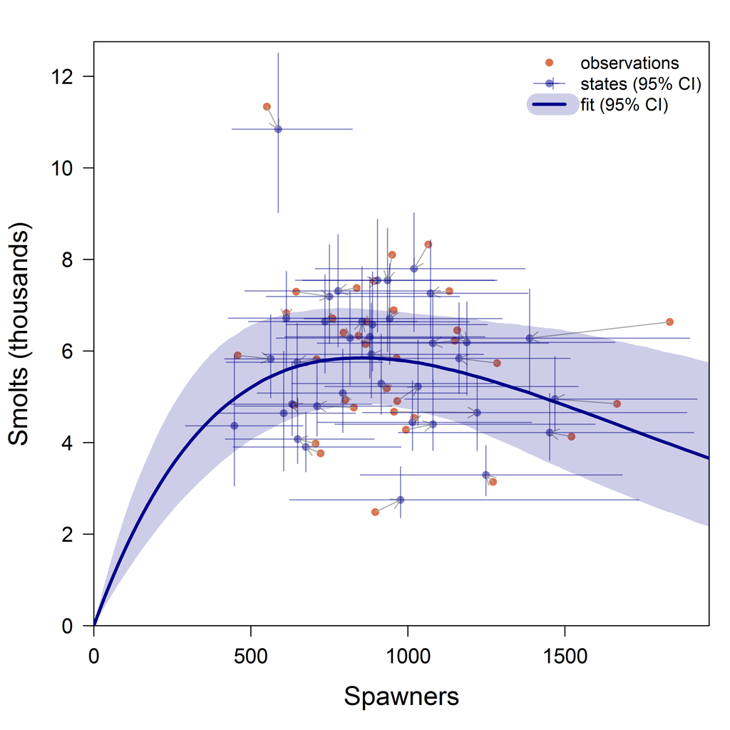

Posterior distributions of spawner-recruit parameters, with priors overlaid

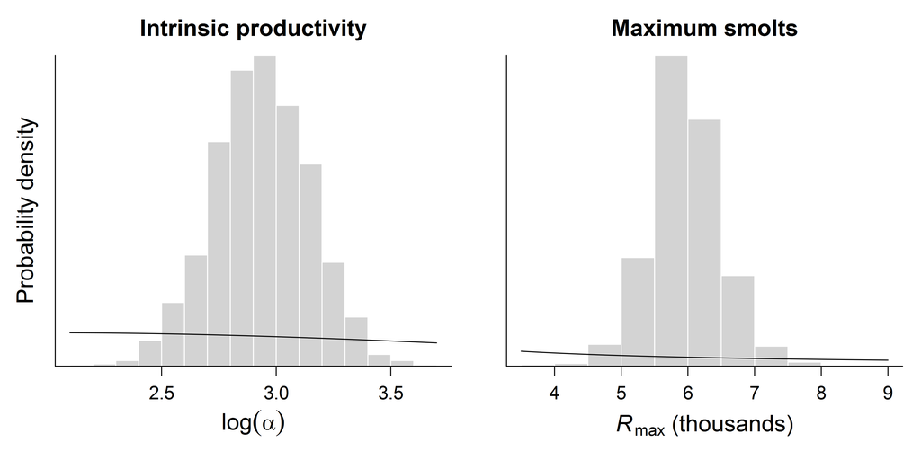

Time series of observed smolt and spawner abundance with estimated states

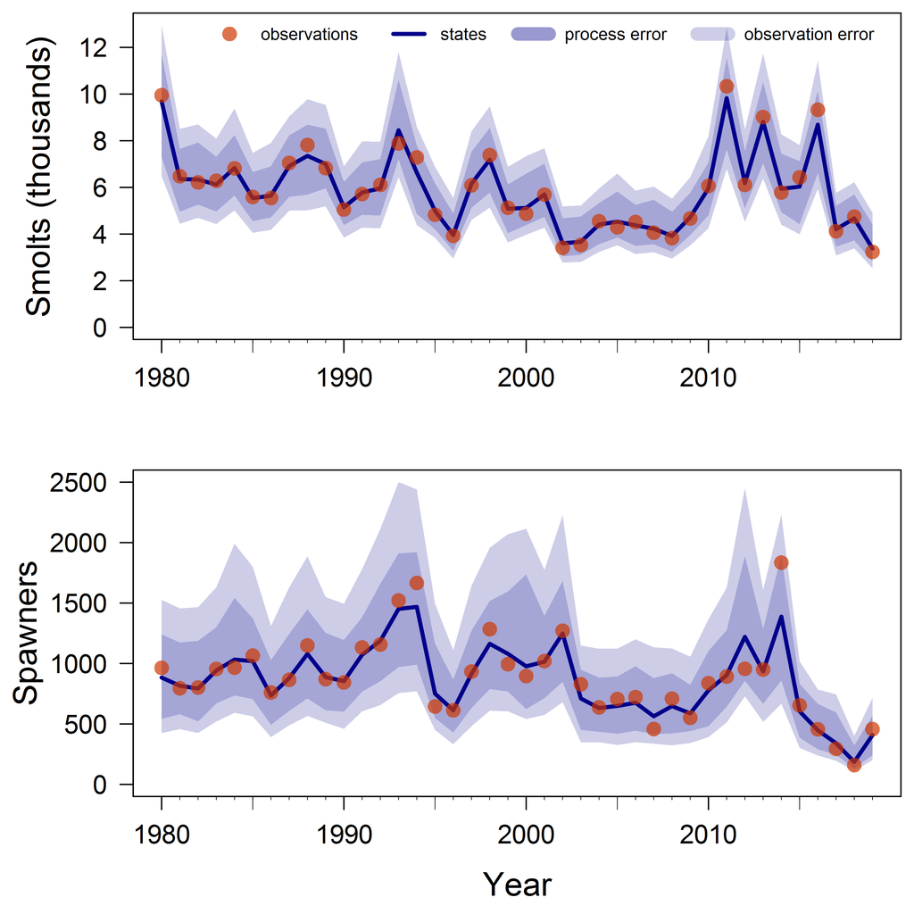

Time series of observed and estimated smolt and spawner age structure

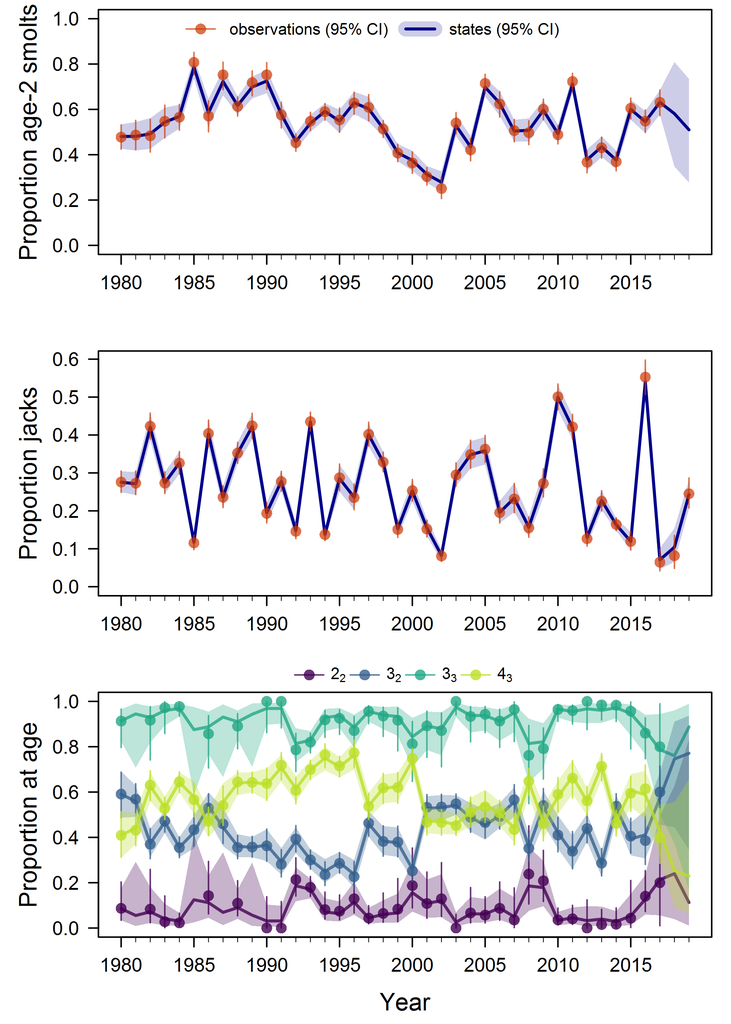

Time series of smolt recruitment process error residuals and the proportion of smolts from each cohort that outmigrated at age 2.

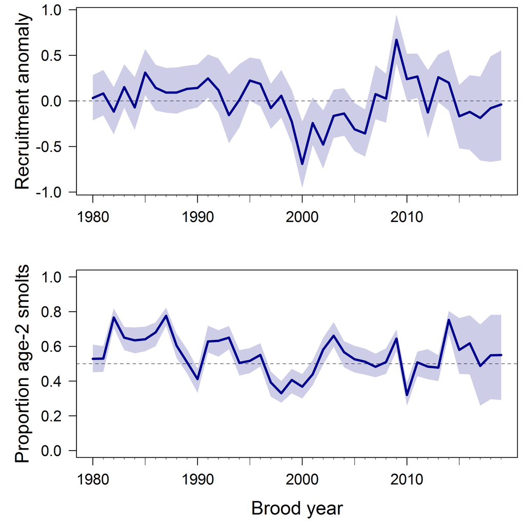

Time series of smolt-to-adult survival for 2- and 3-year-old smolts, and the proportion of each smolt age that return as jacks rather than overwintering at sea.

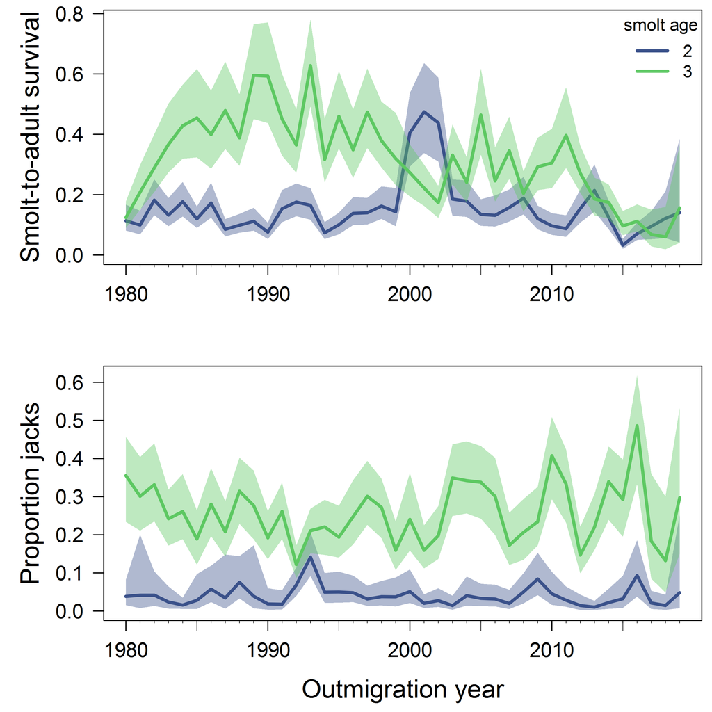